# Business Employee Expenses

Analysis & Modeling

Author

Paula López Casado

Published

September 5, 2024

# Introduction

Managing employee expenses by hand can be a real headache. It eats up valuable time and keeps people in repetitive tasks instead of focusing on what really matters. Using technology that automates the tedious stuff can help to make the whole process smoother and more efficient. This isn’t just about reducing paperwork; it’s about helping teams shift their attention to the bigger financial picture and empowering them to make better decisions for the company.

# Objective

In this project we **analyse business spending trends** based on a dummy business expenses dataset and we propose a **Machine Learning predictive model** to determine the expenses that need human attention.

# Key Insights

**Key insights**

# Part 1) Data Exploration

```python
# Import libraries
from mizani.formatters import label_date, label_currency  # Label currencies in ggplot
import pandas as pd  # Data manipulation
import numpy as np
from forex_python.converter import CurrencyRates # Currency converter
import yahoo_fin.stock_info as si  # Import Yahoo Stock historical data
from datetime import date, datetime, timedelta  # Handle date and time operations

# Model
from sklearn.model_selection import train_test_split, GridSearchCV, cross_val_score
from sklearn.ensemble import GradientBoostingClassifier
from sklearn.metrics import accuracy_score, precision_score, recall_score, f1_score, confusion_matrix, classification_report
from sklearn.preprocessing import LabelEncoder

# Plot necessary functions from plotnine to plot
from plotnine import (ggplot, aes, theme_minimal, element_blank, element_line, element_text, theme, theme_set, options, geom_line, geom_point, geom_text, geom_col, geom_boxplot, geom_tile, geom_hline, scale_fill_gradient, scale_x_date, scale_x_discrete, scale_y_continuous, labs, scale_fill_manual, scale_color_manual, facet_wrap)
```

```python
# Define a font
main_font = "Helvetica Neue"

# Figure Size
options.figure_size = (9, 6)
options.dpi = 200

# Define ggplot theme
def expenses_ggplot_theme():
    return (theme_minimal() +
            theme(panel_grid_minor=element_blank(),
                  panel_grid_major_x=element_blank(),
                  panel_grid_major=element_line(linewidth=0.25),
                  panel_background=element_blank(),
                  axis_title=element_text(family=main_font),
                  axis_text=element_text(family=main_font),
                  axis_ticks_x=element_line(),
                  legend_position='bottom',
                  strip_text=element_text(family=main_font, face="bold", hjust=0.5, size=12),
                  plot_title=element_text(family=main_font, face="bold", hjust=0.5, size=18),
                  plot_subtitle=element_text(family=main_font, face="italic", hjust=0.5))
            )

# Set plotnine theme
theme_set(expenses_ggplot_theme())

# Define the colors in RGB format
expenses_colors = ["#415a77","#e9c46a","#2a9d8f","#e76f51"]
```

## Load Data

```python
# Load the dataset
df = pd.read_csv("expenses.csv")

# Display the first few rows of the dataset
df.head()
```

```
   expense_id  team_id  ... has_note category
0       58062    34523  ...        0   Travel
1       92800    19445  ...        0   Travel
2       83338     5240  ...        0   Travel
3       25976    19445  ...        0   Travel
4       34666    19445  ...        1   Travel

[5 rows x 10 columns]
```

## Feature Engineering

### Check missing values

```python
# Check for missing values
df.isnull().sum()
```

```
expense_id            0
team_id               0
expense_created_at    0
review_status         0
purchase_type         0
amount_value          0
amount_currency       0
merchant_country      0
has_note              0
category              0
dtype: int64
```

There are no missing values, then no action is required.

### Transform date column

```python
# Convert 'expense_created_at' column to datetime with UTC timezone, coercing errors to NaT
df['expense_created_at_as_dt'] = pd.to_datetime(df['expense_created_at'], utc=True, errors='coerce')

# Select rows with NaN values in any column
df_aux = df[df.isnull().any(axis=1)]

# Convert 'expense_created_at' column of the selected rows to datetime with UTC timezone, coercing errors to NaT
df_aux_datetime = pd.to_datetime(df_aux['expense_created_at'], utc=True, errors='coerce')

# Combine 'expense_created_at_as_dt' column of the original DataFrame with 'expense_created_at_as_dt' column of the selected rows, filling NaN values in the original DataFrame with corresponding values from the selected rows
df['expense_created_at_as_dt'] = df_aux_datetime.combine_first(df['expense_created_at_as_dt'])

# Add 'month' column formatted as "Month Year"
df['month'] = df['expense_created_at_as_dt'].dt.to_period('M')
```

### Convert all currencies to EUR

There are several amount currencies, so it is required to transform all currencies to EUR to be able to compare different expenses. There are several ways to convert currencies.

1. Use an API to obtain for each date the expense currency. The library `forex_python` uses https://theforexapi.com, a free API for current and historical foreign exchange rates published by European Central Bank (ECB). This option has two main problems: first, not all currencies in the dataset are available, and second, the time of execution is higher than 20 mins, so we discarded this solution.
2. Retrieve daily historical currency prices for the year 2023 from Yahoo Finance’s forex market data. Then, integrate this exchange rate data with the main dataset by merging the two datasets. Execution time is reduced to seconds.

```python
# # Create a CurrencyRates object
# cr = CurrencyRates()
#
# # Convert each expense amount to Euro (EUR) based on the currency and date of the expense
# converted_expenses = []
# for index, row in df.iterrows():
#     base_currency = row['amount_currency']
#     expense_amount = row['amount_value']
#     expense_date = row['expense_created_at_as_dt']
#
#     try:
#         # Use the convert function to directly convert the expense amount to Euro (EUR)
#         converted_amount = cr.convert(base_currency, 'EUR', expense_amount, expense_date)
#         converted_expenses.append(converted_amount)
#     except Exception as e:
#         print(f"An error occurred during currency conversion for row {index}: {e}")
#         converted_expenses.append(None)
#
# # Add a new column for Euro (EUR) expense amounts to the DataFrame
# df['amount_value_EUR'] = converted_expenses
```

```python
# List unique currencies
list_currencies = df['amount_currency'].unique()

# Keep only currencies different to EUR
list_currencies = [x for x in list_currencies if x != 'EUR']

# Initiate data frame for the exchange rates
df_exchange_rates = pd.DataFrame()

# Fix first and last dates. Get one day before to ensure to have day one of the year
start_period = '2022-12-30'
end_period = '2023-12-31'

# Interval
interval = '1d'

# Init exchanges rates USD/EUR in case the currency exchange rate is not available to EUR
exchange_rates_i_eur = pd.Series([])

# Create a dataframe with all dates of 2023
all_dates = pd.date_range(start=start_period, end=end_period, freq='D')
df_all_dates = pd.DataFrame({'day': all_dates})

for currency in list_currencies:

  print('Currency: ' + currency)

  try:
    exchange_rates_i = si.get_data(currency + 'EUR=X', interval=interval, start_date=start_period, end_date=end_period)['adjclose']

    # If there is no EUR exchange rate available, get the USD exchange rate
  except Exception:
      exchange_rates_i_usd = si.get_data(currency + 'USD=X', interval=interval, start_date=start_period, end_date=end_period)['adjclose']

      # If exchange rate USD/EUR has not been obtained yet, get the rates
      if exchange_rates_i_eur.empty:
        exchange_rates_i_eur = si.get_data('USDEUR=X', interval=interval, start_date=start_period, end_date=end_period)['adjclose']

      # Calculate the exchange rate in EUR by XXX/USD * USD/EUR, where XXX is the current currency
      exchange_rates_i = exchange_rates_i_usd * exchange_rates_i_eur

  # Transform to data frame
  df_exchange_rates_i = exchange_rates_i.to_frame(name='exchange_rate_EUR')

  # Move indexes to a column
  df_exchange_rates_i.reset_index(inplace=True)

  # Rename the date column to 'day'
  df_exchange_rates_i.rename(columns={'index': 'day'}, inplace=True)

  # Merge all 2023 dates with exchange rates
  df_exchange_rates_i = pd.merge(df_all_dates, df_exchange_rates_i, on='day', how='left')

  # Fill missing exchange rates with the last available
  df_exchange_rates_i['exchange_rate_EUR'] = df_exchange_rates_i['exchange_rate_EUR'].ffill()

  # Add column with the current currency
  df_exchange_rates_i['amount_currency'] = currency

  # Keep only 2023 dates
  df_exchange_rates_i = df_exchange_rates_i[df_exchange_rates_i['day'].dt.year == 2023]

  # Concatenate current currency exchange rates with the rest of currency rates
  df_exchange_rates = pd.concat([df_exchange_rates, df_exchange_rates_i])
```

```
Currency: GBP
Currency: NOK
Currency: SEK
Currency: DKK
Currency: USD
Currency: PLN
Currency: THB
Currency: ZMW
Currency: IDR
Currency: JPY
Currency: CHF
```

```python
# Localize day column in UTC timezone
df_exchange_rates['day'] = df_exchange_rates['day'].dt.tz_localize('UTC')

# Convert 'day' and 'expense_created_at_as_dt' columns to date format
df_exchange_rates['day'] = df_exchange_rates['day'].dt.date
df['day'] = df['expense_created_at_as_dt'].dt.date

# Merge DataFrames 'df' and 'df_exchange_rates' based on 'day' and 'amount_currency' columns
df = pd.merge(df, df_exchange_rates, how='left', on=['day', 'amount_currency'])
```

We expect `exchange_rate_EUR == NaN` for all EUR currencies.

```python
# Check if all amount_currency == EUR for all null values in exchange_rate_EUR
df[df.isna().any(axis=1)]['amount_currency'].unique() == 'EUR'
```

```
array([ True])
```

```python
# Fill NaN values in column 'exchange_rate_EUR' with 1
df['exchange_rate_EUR'] = df['exchange_rate_EUR'].fillna(1)

# Convert each amount value by the exchange rate
df['amount_value_EUR'] = df['amount_value'] * df['exchange_rate_EUR']

df[['amount_value','amount_currency','amount_value_EUR']].head()
```

```
   amount_value amount_currency  amount_value_EUR
0     157.88032             GBP        182.954878
1     302.35884             GBP        351.440760
2      95.35440             GBP        111.777289
3     143.50600             GBP        163.327057
4     234.23500             GBP        272.087375
```

## Spending over time

Let’s analyse how much is spent over time.

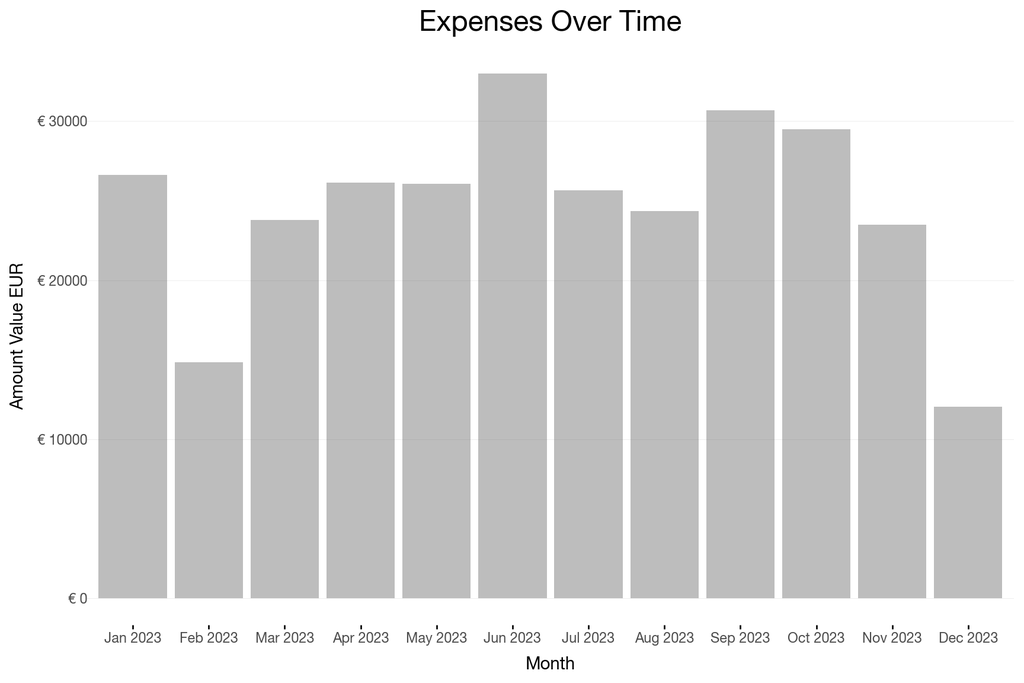

```python
# Total Expenses by month
total_expense_per_month = df.groupby(['month'])['amount_value_EUR'].sum().reset_index()

(ggplot(total_expense_per_month, aes(x='month', y='amount_value_EUR')) +
    geom_col(alpha = 0.4) +
    scale_x_discrete(labels=label_date("%b %Y")) +
    scale_y_continuous(labels=label_currency(prefix = "€ ", accuracy=0)) +
    labs(title='Expenses Over Time', x='Month', y='Amount Value EUR')
).show()
```

There are no major differences in the total amount expended by month. February and December are the months with the lowest spending, ~€15K. In June, spending exceed €30K so we can deep dive on the daily trend.

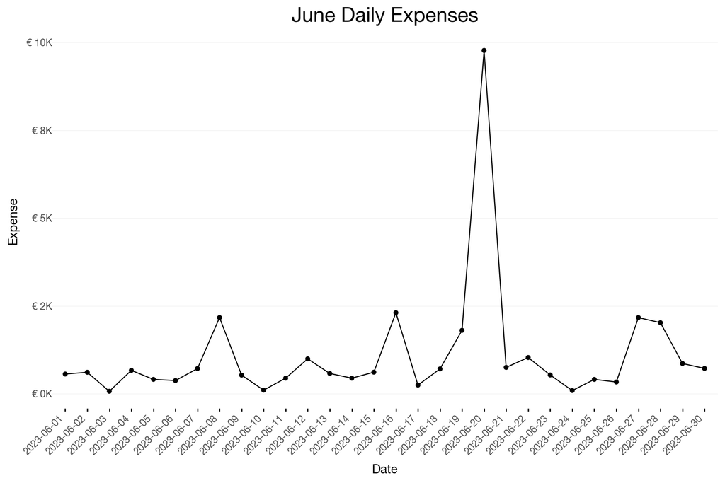

```python
# Calculate daily expenses in June 2023
june_daily_expenses = df[df['month'] == '2023-06-01'].groupby('day')['amount_value_EUR'].sum().reset_index()

(ggplot(june_daily_expenses, aes(x='day', y='amount_value_EUR/1000', group=1)) +
    geom_line() +
    geom_point() +
    labs(title='June Daily Expenses', x='Date', y='Expense') +
    theme(axis_text_x = element_text(angle=45, hjust=1), legend_position='top') +
    scale_y_continuous(labels=label_currency(prefix = "€ ", suffix="K", accuracy=0))
).show()
```

During June 2023 expenses are lower than €2K, except for June 20th, when expenses are almost raising €10K. We filter the initial data to find the expense/s associated:

```python
df[(df['month'] == '2023-06-01') & (df['amount_value_EUR'] > 9000)]
```

```
     expense_id  team_id  ... exchange_rate_EUR amount_value_EUR
954       31618    19445  ...           1.16885      9501.398863

[1 rows x 15 columns]
```

The event corresponds to an expense of the team 19445 of €9501 of the category `Events`.

Finally, we suppose teams have different behaviour in terms of spending over time. Some of them probably have recurrent expenses, and others, more variability in the way they spend. Let´s explore in a visualization if the hypothesis is true.

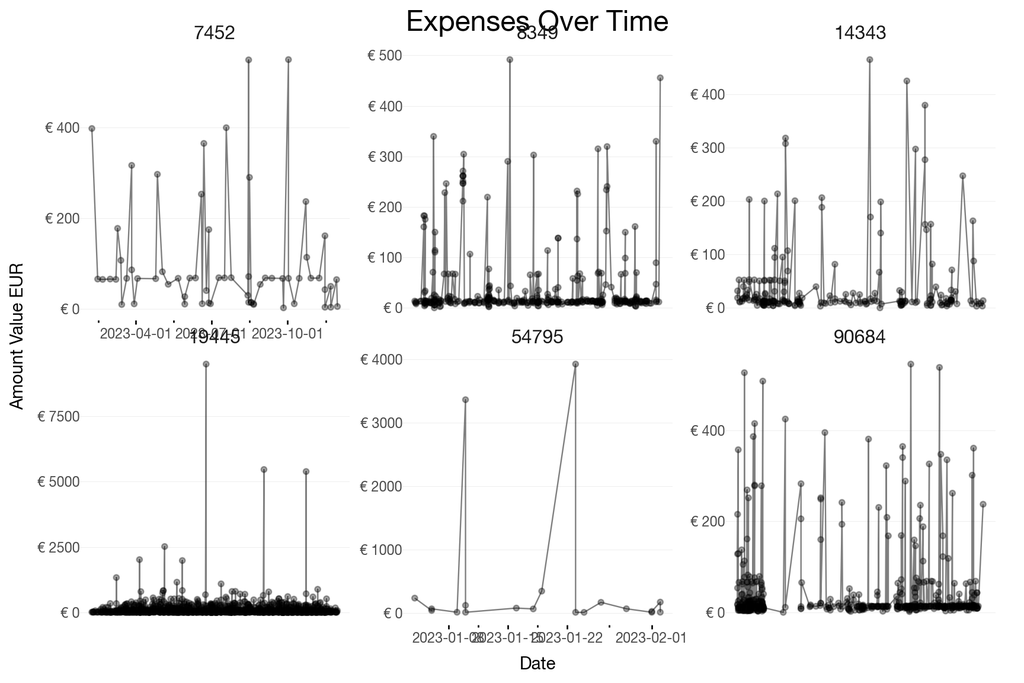

```python
# Line and point plot for the expenses over time for the top 6 teams
(ggplot(df[df['team_id'].isin([19445, 90684, 8349, 14343, 54795, 7452])], aes(x='day', y='amount_value_EUR', group = 'team_id')) +
    geom_point(alpha = 0.35) + geom_line(alpha = 0.5) + facet_wrap('team_id', scales = "free") +
    scale_x_date() +
    scale_y_continuous(labels=label_currency(prefix = "€ ", accuracy=0)) +
    labs(title='Expenses Over Time', x='Date', y='Amount Value EUR')
).show()
```

As we can see in the plot, there are expenses recurrent along time. For example, team 7452 has several expenses with similar value across different months.

## What are the most common categories?

Let´s explore which are the most common categories and the median and total spending by category.

```python
# Group by category and calculate median and total spend
category_summary = df.groupby('category')['amount_value_EUR'].agg(['count', 'median', 'sum']).sort_values(by='sum', ascending=False)

# Calculate total spend
total_spend = category_summary['sum'].sum()

# Calculate percentage spend per category
category_summary['percentage_spend'] = (category_summary['sum'] / total_spend) * 100

category_summary
```

```
                count      median            sum  percentage_spend
category
Travel            505  204.662746  110744.794296         37.398740
Events            502   49.959152   93287.320517         31.503316
Lunch            2790   12.572874   65022.568963         21.958253
Meals & Drinks   1501   12.915540   27064.365996          9.139691
```

`Lunch` is the category most common with more than 53% (2790) expenses followed by Meal & Drinks, 28%. Nevertheless, `Travel` is the category where the company expense the most, as it could be expected. Travel amount is higher than €110K (37%) followed by `Events`, €93K (31%). `Meal and Drinks` is the category with the lower spending, just €27K (9%).

### Lunch

After reviewing the main statistics, it could be interesting to see the distribution of the expenses by month.

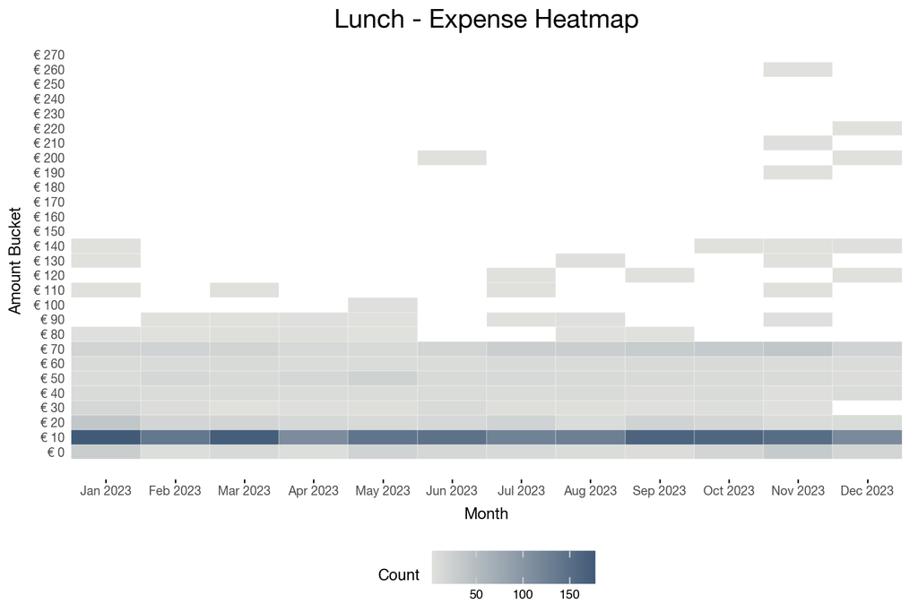

```python
# Add 'amount_bucket' column rounded to the nearest 10
df['amount_bucket'] = (df['amount_value_EUR'] / 10).round(0)

# Filter by lunch category
df_lunch = df.loc[df['category'] == "Lunch"]

# Count occurrences of each combination of 'month', and 'amount_bucket'
df_lunch_count = df_lunch.groupby(['month', 'amount_bucket']).size().reset_index(name='n')

# Plot the heatmap
(ggplot(df_lunch_count, aes(x='month', y='amount_bucket * 10', fill='n')) +
 geom_tile(color="white") +
 scale_fill_gradient(low="#e0e1dd", high="#415a77") +
 theme(panel_grid_minor=element_blank(), panel_grid_major=element_blank()) +
 scale_x_discrete(labels=label_date("%b %Y")) +
 scale_y_continuous(breaks=range(0, 301, 10), labels=label_currency(prefix = "€ ", accuracy=0)) +
 labs(x="Month", y="Amount Bucket", fill="Count", title="Lunch - Expense Heatmap")).show()
```

Most common `Lunch` expenses are between €10-€20. In general, `Lunch` expenses are lower than €100, but in some cases the amount increase over €200 in the months of June, November and December.

### Meals & Drinks

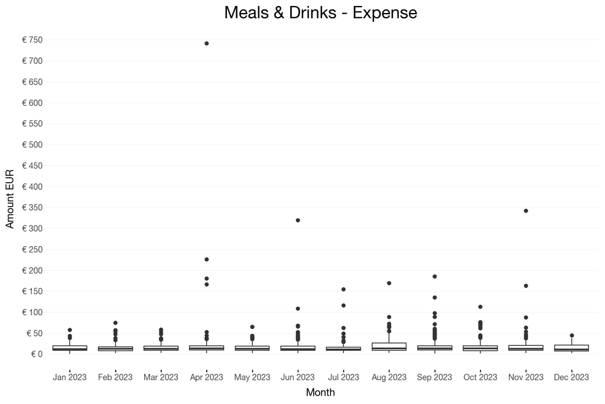

```python
# Filter by lunch category
df_meals = df.loc[df['category'] == "Meals & Drinks"]

# Count occurrences of each combination of 'month', and 'amount_bucket'
df_meals_count = df_meals.groupby(['month', 'amount_bucket']).size().reset_index(name='n')

# Monthly boxplot of the meals and drinks expenses (EUR)
(ggplot(df_meals, aes(x='month', y='amount_value_EUR')) +
  geom_boxplot() +
  scale_x_discrete(labels=label_date("%b %Y")) +
  scale_y_continuous(breaks = range(0, 801, 50), labels=label_currency(prefix = "€ ", accuracy=0)) +
  labs(x="Month", y="Amount EUR", fill="Count", title="Meals & Drinks - Expense")).show()
```

Meal expenses are normally lower than €50. Nevertheless, there are few outliers with remarkable high value. One of them close to €750 and the other two around €300-€350.

### Travel

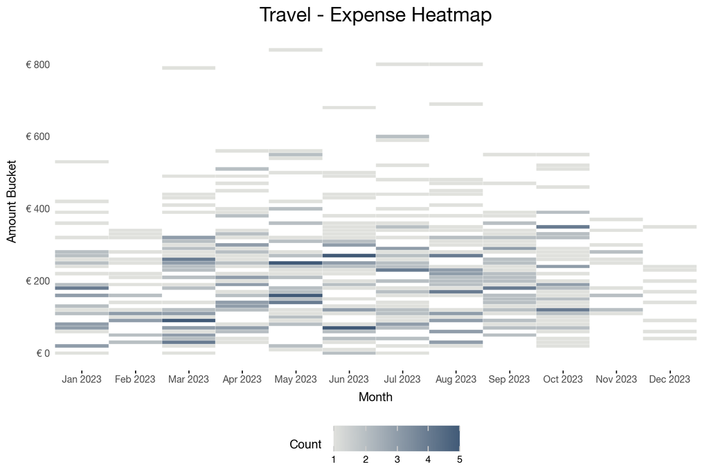

```python
# Filter category Travel
df_travel = df.loc[df['category'] == "Travel"]

# Count occurrences of each combination of 'month' and 'amount_bucket'
df_travel_count = df_travel.groupby(['month', 'amount_bucket']).size().reset_index(name='n')

# Plot the heatmap
(ggplot(df_travel_count, aes(x='month', y='amount_bucket * 10', fill='n')) +
   geom_tile(color="white") +
   scale_x_discrete(labels=label_date("%b %Y")) +
   scale_y_continuous(labels=label_currency(prefix="€ ", accuracy=0)) +
   scale_fill_gradient(low="#e0e1dd", high="#415a77") +
   theme(panel_grid_minor=element_blank(), panel_grid_major=element_blank()) +
   labs(x="Month", y="Amount Bucket", fill="Count", title="Travel - Expense Heatmap")).show()
```

There are no specific patterns for `Travel` category. In general, expenses are higher than in other categories like `Lunch` or `Meal & Drinks` up to €838. Most common expenses are between €100-€400 spread throughout the year.

### Events

`Events` category will be analysed in the next section about team spending.

## How spendings are made: online or in store?

```python
# Count by purchase type
purchase_type_counts = df['purchase_type'].value_counts()

# Percentage by purchase type
purchase_type_percentage = (purchase_type_counts / len(df)) * 100
purchase_type_percentage
```

```
purchase_type
IN_STORE    79.331823
ONLINE      20.668177
Name: count, dtype: float64
```

The most common way to purchase is `IN STORE` with a 79% of the purchases. Only 21% of the expenses are arranged `ONLINE`.

## How much does each team spend?

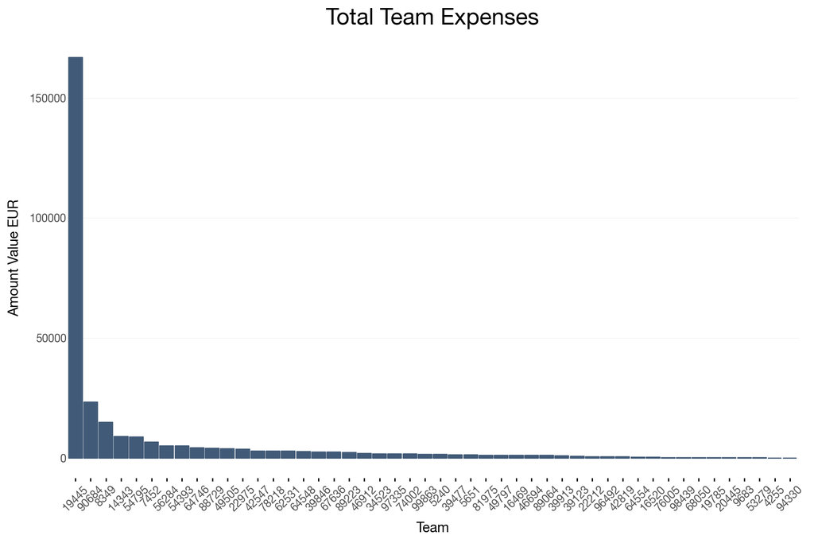

```python
# Summarize the data
total_expense = df.groupby('team_id')['amount_value_EUR'].sum().reset_index()

# Transform team_id to categorical
total_expense['team_id'] = pd.Categorical(total_expense['team_id'])

# Plot the total expense by team
(ggplot(total_expense, aes(x = 'reorder(team_id, -amount_value_EUR)', y = 'amount_value_EUR')) +
  geom_col(color = expenses_colors[0], fill = expenses_colors[0]) +
  theme(axis_text_x = element_text(angle=45)) +
  labs(x="Team", y="Amount Value EUR", title="Total Team Expenses")).show()
```

Team 19445 stands out with significantly higher spending compared to the other teams.

```python
# Calculate the percentage
total_expense['percentage'] = (total_expense['amount_value_EUR'] / total_expense['amount_value_EUR'].sum()) * 100

# Sort the dataframe by total expense in descending order
total_expense = total_expense.sort_values(by='amount_value_EUR', ascending=False)

# Reset index
total_expense.reset_index(drop=True, inplace=True)

# Display the table
total_expense.head()
```

```
  team_id  amount_value_EUR  percentage
0   19445     166791.548343   56.325842
1   90684      23232.447409    7.845644
2    8349      14750.000970    4.981105
3   14343       8908.734963    3.008498
4   54795       8750.590728    2.955092
```

### How much teams spends on events and travels?

```python
# Filter rows where category is "Events"
df_events = df[df['category'] == 'Events']

# Group by team_id and sum amount_value_EUR
total_by_team = df_events.groupby('team_id')['amount_value_EUR'].sum().reset_index()

# Calculate percentage of total for each team
total_by_team['pct'] = (total_by_team['amount_value_EUR'] / total_by_team['amount_value_EUR'].sum())*100

# Sort by total in descending order
total_by_team.sort_values(by='amount_value_EUR', ascending=False).head()
```

```
    team_id  amount_value_EUR        pct
5     19445      64053.654092  68.662765
17    54795       8453.909790   9.062228
2      8349       5158.154025   5.529320
4     14343       2827.259328   3.030701
29    90684       2742.247584   2.939572
```

The team who has the higher expense in `Events` is 19445. 69% of the total expense is accounted to this team.

```python
# Filter rows where category is "Travel"
df_travel = df[df['category'] == 'Travel']

# Group by team_id and sum amount_value_EUR
total_by_team = df_travel.groupby('team_id')['amount_value_EUR'].sum().reset_index()

# Calculate percentage of total for each team
total_by_team['pct'] = (total_by_team['amount_value_EUR'] / total_by_team['amount_value_EUR'].sum())*100

# Sort by total in descending order
total_by_team.sort_values(by='amount_value_EUR', ascending=False).head()
```

```
    team_id  amount_value_EUR        pct
7     19445      59623.114410  53.838300
33    90684      12341.637927  11.144215
3      8349       5064.913891   4.573501
4     14343       3377.824848   3.050098
21    54393       2798.776519   2.527231
```

## Where the company spends the most?

Let´s now review the countries more expensive for the company, or better said, where are located most of the expenses and which countries have the higher amount.

```python
# Group by merchant_country and calculate total amount and count
df_country = df.groupby('merchant_country').agg(total_amount=('amount_value_EUR', 'sum'), n=('amount_value_EUR', 'count'))

# Calculate percentage of total amount and count
total_amount_sum = df_country['total_amount'].sum()
count_sum = df_country['n'].sum()
df_country['pct_amount'] = (df_country['total_amount'] / total_amount_sum)*100
df_country['pct'] = (df_country['n'] / count_sum)*100

# Arrange the DataFrame by total amount in descending order
df_country.sort_values(by='pct_amount', ascending=False)
```

```
                   total_amount     n  pct_amount        pct
merchant_country
GB                218644.273957  3656   73.836612  69.007173
PT                 25210.604244   576    8.513672  10.872027
DK                 11838.269297   278    3.997807   5.247263
ES                  9992.664212   157    3.374543   2.963382
NO                  6799.829138    31    2.296316   0.585126
DE                  4852.260928   128    1.638618   2.416006
NL                  4025.490847    89    1.359416   1.679879
SE                  2891.416778    95    0.976437   1.793129
IE                  2813.153528    34    0.950008   0.641752
FR                  1758.482200    62    0.593843   1.170253
BE                  1639.253620    27    0.553579   0.509626
CZ                  1182.159551     4    0.399218   0.075500
LU                  1010.160494    15    0.341133   0.283126
PL                   874.099626    23    0.295185   0.434126
TH                   504.171230    38    0.170260   0.717252
US                   472.052136    11    0.159413   0.207626
EE                   341.092272    19    0.115188   0.358626
SK                   166.061108     2    0.056079   0.037750
FI                   157.939620     4    0.053337   0.075500
ZM                   142.482277    14    0.048117   0.264251
BQ                   132.254129     2    0.044662   0.037750
GR                   130.531160    10    0.044081   0.188750
IT                   106.929760     3    0.036110   0.056625
ID                    98.717405    10    0.033337   0.188750
CA                    88.690976     1    0.029951   0.018875
HR                    73.532000     2    0.024832   0.037750
IS                    58.563782     2    0.019777   0.037750
CH                    52.917273     2    0.017870   0.037750
MU                    32.340378     2    0.010921   0.037750
IN                    28.655848     1    0.009677   0.018875
```

Great Britain (GB) is the country where the teams expense more in total, 74%. Portugal (PT) follows the ranking with 8% of the amount expended, followed by Denmark (4%) and Spain (3%). In terms of number of expenses, similar order of merchant country is followed. Something remarkable is the case of Norway. The country has the 0.5% of the expenses but only 2% of total amount expended, that means probably Norwegian expenses are higher than the mean.

### Merchant Country & Category

```python
# Group by category and merchant_country, calculate total money and count
df_cat_country = df.groupby(['category','merchant_country']).agg(total_amount=('amount_value_EUR', 'sum'), n=('amount_value_EUR', 'count')).reset_index()

# Calculate percentage of total money and count
total_amomunt_sum = df_cat_country['total_amount'].sum()
count_sum = df_cat_country['n'].sum()
df_cat_country['pct_amount'] = df_cat_country['total_amount'] / total_amomunt_sum
df_cat_country['pct'] = df_cat_country['n'] / count_sum
df_cat_country.sort_values(by='total_amount', ascending=False).head()
```

```
          category merchant_country  total_amount     n  pct_amount       pct
56          Travel               GB  91248.667677   397    0.308149  0.074934
5           Events               GB  61933.125676   311    0.209149  0.058701
24           Lunch               GB  57989.570031  2425    0.195832  0.457720
12          Events               PT  13810.810106    77    0.046639  0.014534
41  Meals & Drinks               GB   7472.910573   523    0.025236  0.098716
```

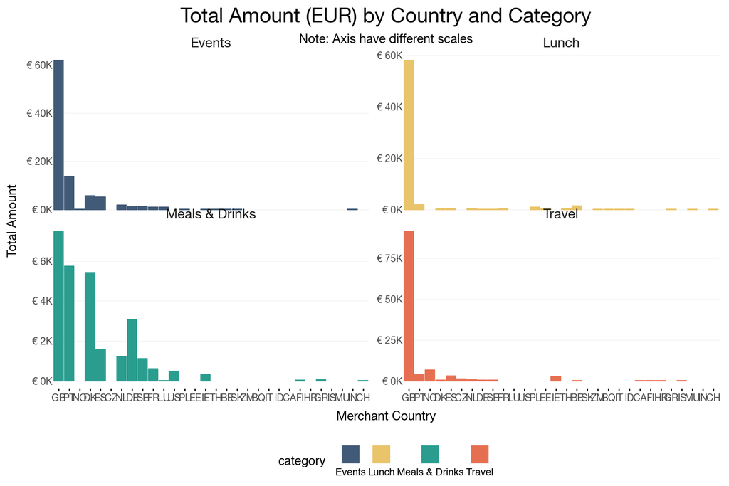

```python
# Sort values by total amount descending
df_cat_country = df_cat_country.sort_values(by='total_amount', ascending = False)

# PLot total expenses by country and category
(ggplot(df_cat_country, aes(x='reorder(merchant_country, -total_amount)', y='total_amount/1000', fill = 'category', color = 'category')) +
    geom_col() +
    scale_color_manual(values=expenses_colors) +
    scale_fill_manual(values=expenses_colors) +
    scale_y_continuous(labels=label_currency(prefix="€ ", suffix = "K", accuracy=0)) +
    facet_wrap('category', scales='free_y') +
    labs(x="Merchant Country", y="Total Amount", title="Total Amount (EUR) by Country and Category", subtitle="Note: Axis have different scales")).show()
```

**Warning**

Note y-axis has free scales.

**Most common**. `Lunch` in GB is the most common expense category with a 46% of the expenses, followed by `Meal & Drinks` and `Travel` in GB as well, 10% and 7% respectively.

**Total Expenses**. GB has 70% of total expenses where 30% (€91K) is for `Travelling`, 20% (€61K) for `Events` and 20% (€58K) for `Lunch.`

**Category Distribution**. In terms of total amount distribution by country & category, GB highlights in all categories compared to the second in the ranking, Portugal or Norway in `Travel` expenses.

Based on the data, the company seems to be situated in GB or at least with a high amount of business in this country due to most of the merchants of the submitted expenses are located there.

## Unsual expenses

```python
# Group by category and merchant_country, calculate total_money and count
grouped_df = df.groupby(['category','merchant_country']).agg(total_money=('amount_value_EUR', 'sum'), n=('amount_value_EUR', 'count')).reset_index()

# Arrange by total_money in descending order
sorted_df = grouped_df.sort_values(by='total_money', ascending=False)

# Calculate percentage of total money and count
total_money_sum = sorted_df['total_money'].sum()
count_sum = sorted_df['n'].sum()
sorted_df['pct_money'] = sorted_df['total_money'] / total_money_sum
sorted_df['pct'] = sorted_df['n'] / count_sum

# Filter rows where pct is less than 0.01
sorted_df[sorted_df['pct'] < 0.01].head()
```

```
   category merchant_country  total_money   n  pct_money       pct
61   Travel               NO  6737.772217  30   0.022754  0.005663
2    Events               DK  5716.295305  22   0.019304  0.004153
3    Events               ES  5159.663165  29   0.017424  0.005474
62   Travel               PT  3699.748438  22   0.012494  0.004153
54   Travel               ES  2884.274478  11   0.009740  0.002076
```

There are some other unusual expenses (number of occurrences < 1%) such as 30 travels to Norway with a total spend of €7K, as well as events in Denmark (DK) with a total value of €6K, and Spain (ES) €5K.

## Expenses to review

For the dates extracted from `expense_created_at` we can deduce how long some expenses have been waiting for reviewer. One of the main goals of the exercise is to help to reduce this waiting approval time. Let´s analyse the correlation between days waiting for approval of an expense and the amount value in EUR.

```python
# Calculate the number of days since the expense was created until December 31, 2023
df['days_since_creation'] = (pd.to_datetime('2023-12-31', utc=True) - df['expense_created_at_as_dt']).dt.days
```

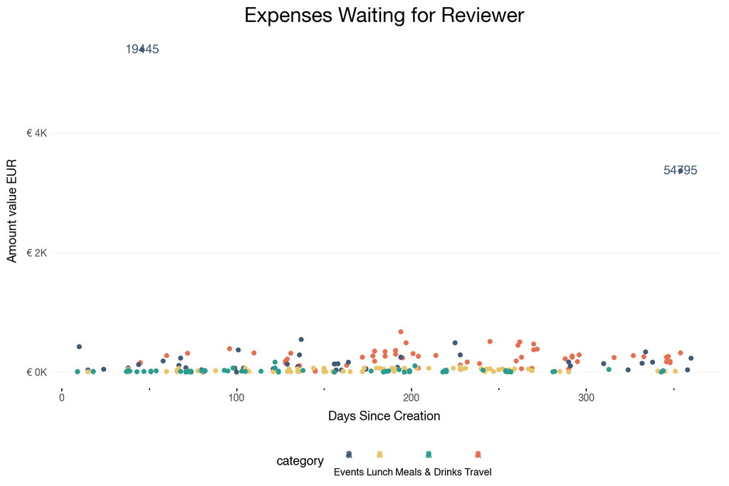

```python
# Plot expenses waiting for reviewer
(ggplot(df[df['review_status'] == "WAITING_FOR_REVIEWER"], aes(x='days_since_creation', y='amount_value_EUR/1000', color='category')) +
  geom_point() +
  geom_text(data=df[(df['review_status'] == "WAITING_FOR_REVIEWER") & (df['amount_value_EUR'] > 2000)], mapping=aes(x='days_since_creation', y='amount_value_EUR/1000', label='team_id')) +
  scale_color_manual(values=expenses_colors) +
    scale_y_continuous(labels=label_currency(prefix="€ ", suffix = "K", accuracy=0)) +
  labs(title="Expenses Waiting for Reviewer", x="Days Since Creation", y="Amount value EUR")
).show()
```

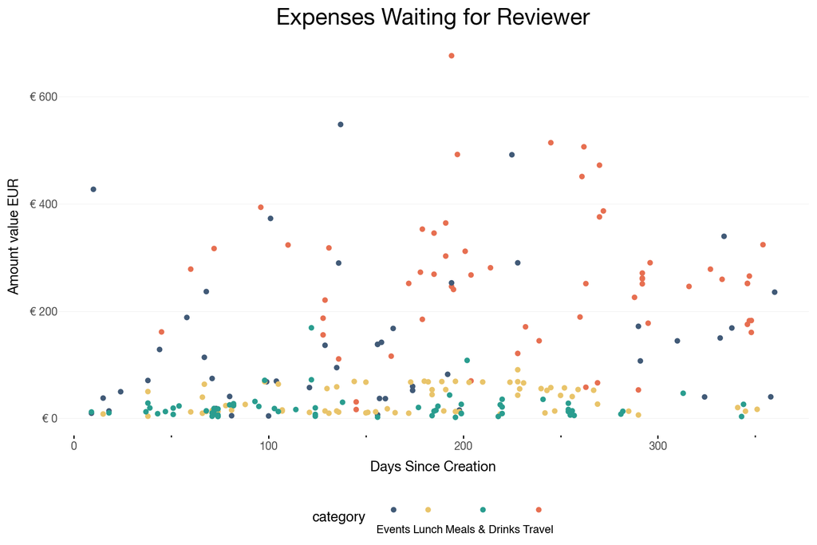

```python
# Plot expenses waiting for reviewer - filtering lower than 2K
(ggplot(df[(df['review_status'] == "WAITING_FOR_REVIEWER") & (df['amount_value_EUR'] < 2000)], aes(x='days_since_creation', y='amount_value_EUR', color='category')) +
  geom_point() +
  scale_color_manual(values=expenses_colors) +
    scale_y_continuous(labels=label_currency(prefix="€ ", accuracy=0)) +
  labs(title="Expenses Waiting for Reviewer", x="Days Since Creation", y="Amount value EUR")
).show()
```

There are two expenses from team 19445 and 54795 around €4K that highlight from the rest of expenses. The last one has been waiting for review more than 350 days.

Expenses waiting for reviewer are from all categories in a balanced way. The amount value is higher for `Events` and `Travel` categories, compared with `Lunch` and `Meal & Drinks` categories.

The average waiting time is 176 days and the days since creation of the expense that has been waiting the most is 360 days, practically one year waiting for approval.

## Conclusions

The exploratory data analysis reveals several important spending patterns that provide a strong foundation for future improvements in the expense management process. Key trends show that spending is concentrated among a few teams and countries, with Team 19445 and Great Britain leading in total expenses. This highlights the importance of focusing resources on these areas for further analysis and optimization. Additionally, the uneven distribution of expenses throughout the year, with spikes in certain months, suggests opportunities for better financial planning and forecasting.

The data also points to some outlier expenses, such as significant event costs and unusual travel expenses, which may warrant closer scrutiny or policy changes. Automating the process will not only streamline routine approvals but also help flag these atypical expenses more efficiently. Moreover, the long average waiting time for expense approvals indicates that the current manual process is causing delays that could impact financial visibility and decision-making.

Overall, the insights gathered from this analysis emphasize the need for a more dynamic and automated expense management system that prioritizes high-cost teams and categories while reducing delays and enhancing the company’s ability to manage finances proactively. This will allow finance teams to focus on strategic decision-making and improve overall efficiency.

# Part 2) Business Spending Scoring System

We aim to detect those expenses that needs human attention. For these task, we propose a **ranking model** to estimate the *priority to review* given the option of automate the approval process for those cases where indicator is lower than a specific threshold.

**Features Selected**

In base on the data analysed previously, we would include in order of importance. First, the `amount value` of the expense in EUR and the `number of days` since the expense was submitted. Secondly, the `team` as there are some teams that incur the same expenses on a recurring basis. Then, `merchant country` and the `currency` are important as well specially for those cases really unusual such as expenses in Mauritius or in ZMW currency. We suggest to keep the `category` for a segmentation process explained in the next section. Finally other features such as `purchase type` or `has note` could be included as extra features, and we can let the model decide if they have a real impact or not in the target variable.

**Target Variable**

We can use `review_status` as a initial target variable where `OK` or `NOT_REQUIRED` is equivalent to `priority to review = 0` and `WAITING FOR REVIEWER`, `priority to review = 1`. Then, after training the model, we expect to obtain an accurate score value between 0 and 1 that reflects the importance of an expense to be reviewed. This score should help us to determine as well if an expense can be approved automatically when this score is lower certain threshold.

**Segmentation Proposal**

Based on the initial data exploration, we suggest 4 different models based on the **category** of the expense for two different reasons. 1) Expense range is different between categories. For example, 80% of expenses of `Meals & Drinks` are between €5 and €30, however expenses of the `Events` category vary from €11 to €340. 2) Variability of the data, even for a fixed range, is entirely different. `Lunch` category seems to follow more uniform distribution over time. Nevertheless, `Events` has a really **high variability** along time. A similar behaviour is followed by `Travel` expenses. We know a ML model can detect this kind of differences, nevertheless, we consider this feature a very important characteristic of a expense where parameters of the model as well as final threshold would be different between categories.

**Proposed Model**

I propose using a **Gradient Boosting Machine (GBM)** model for predicting expense approval. GBM is a powerful ensemble learning technique that builds decision trees sequentially, each one correcting the errors of the previous trees. GBM models are robust, handle complex relationships well, and typically perform well in classification tasks.

**Evaluation Metrics**

To evaluate the performance of the GBM model, we can use the following metrics:

1. **Accuracy:** Overall correctness of the model in predicting the approval status of expenses.
2. **Precision:** Proportion of correctly predicted approved expenses out of all expenses predicted as approved.
3. **Recall:** Proportion of correctly predicted approved expenses out of all actual approved expenses.
4. **F1-Score:** Harmonic mean of precision and recall, providing a balanced measure of model performance.
5. **Confusion Matrix:** To visualize the true positives, true negatives, false positives, and false negatives.

**Validation Strategy**

We can adopt a cross-validation approach to validate the GBM model. This involves splitting the dataset into multiple subsets, training the model on some subsets, and evaluating its performance on the remaining subset. This process is repeated multiple times, and the average performance metrics are calculated to assess the model’s generalization capability.

**Hyperparameter Tuning**

Hyperparameter tuning is crucial for optimizing the performance of the GBM model. Techniques such as grid search or random search can be employed to search through a range of hyperparameters (e.g., learning rate, tree depth, number of estimators) and find the combination that maximizes the model’s performance metrics.

**Model Interpretability**

Although GBM models tend to be less interpretable compared to simpler models like logistic regression, techniques such as feature importance analysis can provide insights into which features are most influential in predicting priority to review score. This can help in understanding the underlying factors driving approval decisions. To extract the score we can use the function `gbm_classifier.predict_proba()`

**Implementation**

```python
# 1. Feature Selection

# Selecting important features
selected_features = ['amount_value_EUR', 'days_since_creation', 'team_id', 'merchant_country',
                     'amount_currency', 'category', 'purchase_type', 'has_note']

# Encoding categorical features
label_encoder = LabelEncoder()
df['team_id'] = label_encoder.fit_transform(df['team_id'])
df['merchant_country'] = label_encoder.fit_transform(df['merchant_country'])
df['amount_currency'] = label_encoder.fit_transform(df['amount_currency'])
df['category'] = label_encoder.fit_transform(df['category'])
df['purchase_type'] = label_encoder.fit_transform(df['purchase_type'])
df['has_note'] = df['has_note'].astype(int)  # Assuming 'has_note' is a boolean field

# 2. Target Variable

# Creating the target variable based on `review_status`
df['priority_to_review'] = df['review_status'].apply(lambda x: 1 if x == 'WAITING_FOR_REVIEWER' else 0)

# 3. Segmentation Proposal (Splitting data by category)

categories = df['category'].unique()
models = {}
results = {}

for category in categories:
    # Filter data by category
    category_df = df[df['category'] == category]

    # Split data into features (X) and target (y)
    X = category_df[selected_features]
    y = category_df['priority_to_review']

    # Split data into training and testing sets
    X_train, X_test, y_train, y_test = train_test_split(X, y, test_size=0.3, random_state=42)

    # 4. Proposed Model - Gradient Boosting Classifier
    gbm = GradientBoostingClassifier(random_state=42)

    # 5. Hyperparameter Tuning - Grid Search
    param_grid = {
        'learning_rate': [0.01, 0.1, 0.2],
        'n_estimators': [100, 200, 300],
        'max_depth': [3, 5, 7]
    }

    grid_search = GridSearchCV(estimator=gbm, param_grid=param_grid, cv=5, scoring='accuracy', n_jobs=-1)
    grid_search.fit(X_train, y_train)

    # Best model for the category
    best_gbm = grid_search.best_estimator_

    # Store the model for future use
    models[category] = best_gbm

    # Predictions and evaluations
    y_pred = best_gbm.predict(X_test)
    y_proba = best_gbm.predict_proba(X_test)[:, 1]  # Predict probability score

    # 6. Evaluation Metrics
    accuracy = accuracy_score(y_test, y_pred)
    precision = precision_score(y_test, y_pred)
    recall = recall_score(y_test, y_pred)
    f1 = f1_score(y_test, y_pred)
    confusion = confusion_matrix(y_test, y_pred)

    # Store results
    results[category] = {
        'accuracy': accuracy,
        'precision': precision,
        'recall': recall,
        'f1_score': f1,
        'confusion_matrix': confusion,
        'classification_report': classification_report(y_test, y_pred)
    }
```

## Further Steps

By addressing the class imbalance and considering these improvements, the model’s ability to detect expenses that require human review could significantly improve, making the automation process more effective and reliable.